# Flexible Damage Functions

Author

James Rising, Sebastian Cadavid Sanchez, Climate Impact Lab

Published

April 30, 2026

## 0.1 Agriculture: Wheat Combined

Flexible damage function parameters at the Impact Region level.

**Change in wheat yields (log change in yields) under full adaptation**

**Outcome units:** `physical`

$$D_{it} = (\alpha_i T_t + \beta_i T_t^2) \cdot Y_{it}^{\gamma}$$

where $\gamma$ is the income elasticity (fitted globally), $\alpha_i$ is the linear coefficient, and $\beta_i$ is the quadratic coefficient.

# 1 Global Estimation

## 1.1 Income Elasticity Estimation

The income elasticity $\gamma$ is estimated using a fixed-effects regression:

$$y_{it} = \gamma \cdot \log(Y_{it}) + \mu_{g(i,T)} + \nu_t + \varepsilon_{it}$$

where $\mu_{g(i,T)}$ are region-by-temperature-bin fixed effects and $\nu_t$ are year fixed effects.

Table 1: Income Elasticity (Gamma) Estimation Results

| Statistic | Value |
| --- | --- |
| Income elasticity ($\gamma$) | -0.0392 |
| Standard error | 1.59e-03 |
| 95% CI | [-0.0424, -0.0361] |
| R-squared | 0.7780 |
| Observations | 24,681,159 |
| Regions | 24,326 |
| Gamma quantiles | 19 |

# 2 Parameter Distributions

## 2.1 8-Panel Summary

Row 1: gamma, alpha, beta, rsqr1. Row 2: rho, zeta, eta, rsqr2.

```
Using median gamma: -0.039235, 24,326 rows (of 462,194 total)
```

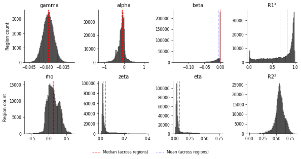

Figure 1: Distribution of Regional Parameters

## 2.2 Projection Equation and Parameter Definitions

The estimated parameters are used to project damages via Monte Carlo sampling:

$$D_{it}^k = (\hat{\alpha}_{ik} T_t + \hat{\beta}_{ik} T_t^2) Y_{it}^{\hat{\gamma}_k} + \hat{\theta}_{ik} T_t Y_{it}^{\hat{\gamma}_k} + \hat{\phi}_{it}^k$$

where $k$ indexes the Monte Carlo draw. The parameters in each row of the output CSV control distinct components of this equation:

- **gamma**: income elasticity $\hat{\gamma}_k$, one of 19 quantile values drawn from $N(\hat{\gamma}, SE(\hat{\gamma}))$
- **alpha, beta**: linear and quadratic temperature coefficients; $\hat{\alpha}_{ik}$ and $\hat{\beta}_{ik}$ are drawn from the joint normal defined by the VCV below
- **sigma11, sigma12, sigma22**: variance-covariance matrix of $(\alpha, \beta)$, used for joint uncertainty sampling
- **rho**: correlation between regional and global polynomial residuals $\rho_i$, used to maintain spatial covariance across regions in Monte Carlo draws
- **zeta**: temperature-dependent error scale $\zeta_{ik}$; the run-specific error term $\hat{\theta}_{ik}$ is drawn from $N(0, \zeta_{ik})$
- **eta**: residual noise standard deviation $\eta_{ik}$; the annual noise $\hat{\phi}_{it}^k$ is drawn from $N(0, \eta_{ik})$
- **rsqr1, rsqr2**: polynomial fit quality and error model fit, respectively

## 2.3 Summary Statistics

Table 2: Regional Parameter Summary

| Parameter | Mean | Median | Std | Min | Max | N |
| --- | --- | --- | --- | --- | --- | --- |
| alpha | -0.1273 | -0.1005 | 0.1821 | -1.138 | 1.097 | 24,326 |
| beta | -0.008093 | -0.001665 | 0.01308 | -0.1372 | 0 | 24,326 |
| rho | 0.1309 | 0.1148 | 0.1601 | -0.6216 | 0.6529 | 24,303 |
| zeta | 0.03895 | 0.0197 | 0.05155 | 0 | 0.3772 | 24,326 |
| eta | 0.07185 | 0.03452 | 0.09589 | 0 | 0.7507 | 24,326 |
| rsqr1 | 0.6878 | 0.8214 | 0.3053 | 0 | 0.9924 | 24,326 |
| rsqr2 | 0.5648 | 0.5645 | 0.08557 | 0 | 0.835 | 24,326 |

# 3 Spaghetti Curves

Regional damage function curves showing D(T) = αT + βT² for sampled regions.

[interactive chart not shown]

Figure 2: Regional Damage Functions

# 4 Zero Crossings

The zero crossing (extremum) of the parabola occurs at $T^* = -\alpha / (2\beta)$.

Table 3: Zero Crossing Statistics

| Category | Count | Percentage |
| --- | --- | --- |
| β = 0 (no crossing) | 11138 | 45.8% |
| T > 20°C (beyond graph) | 22 | 0.1% |
| T < 0°C (negative crossing) | 9724 | 40.0% |
| Valid crossings (0-20°C) | 3442 | 14.1% |

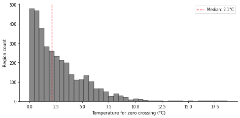

Figure 3: Distribution of Zero Crossing Temperatures

# 5 Slope Analysis

Maximum slope between 0 and 10°C: $\frac{dM}{dT} = \alpha + 2\beta T$

The maximum occurs at either T=0 or T=10 (endpoints of interval).

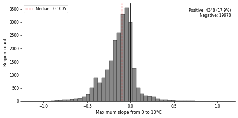

Figure 4: Distribution of Maximum Slopes (0-10°C)

*Convexity analysis omitted (beta constraint active).*

# 6 R-squared Analysis

## 6.1 Polynomial Fit Quality (rsqr1)

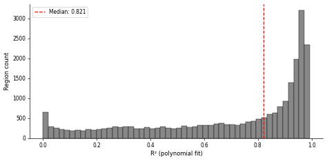

Figure 5: Regional Fit Quality (R-squared)

## 6.2 Error Model R-squared (rsqr2) Quantiles

Table 4: rsqr2 Quantiles

| 0% (Min) | 25% | 50% (Median) | 75% | 100% (Max) |
| --- | --- | --- | --- | --- |
| 0.0000 | 0.5221 | 0.5645 | 0.6142 | 0.8350 |

# 7 Modelled Variance

Modelled variance statistic: $1 - \frac{\sum_i \eta_i^2}{\sum_i D_i^2}$

Table 5: Modelled Variance Statistics

| Statistic | Value |
| --- | --- |
| Modelled variance | 0.9694 |
| Sum(η²) | 349.2313 |
| Sum(D²) at T=3.0°C | 11399.0548 |
| N regions | 24,326 |

# 8 Best- and Worst-Fitting Regions

The 3 worst- and 3 best-fitting regions by R-squared, with raw simulation data overlaid on the fitted polynomial curve. **Red rows = worst fits**, **green rows = best fits**.

Table 6: Best- and worst-fitting regions

Top 3 best fit (R²) Top 3 worst fit (R²)

| Region | α | β | η | R² |
| --- | --- | --- | --- | --- |
| ECU.20.R174226225df846c9 | -0.209 | -0.00709 | 0.0152 | 0.992 |
| ECU.20.192.960 | -0.149 | -0.0146 | 0.0134 | 0.992 |
| ECU.20.192.961 | -0.147 | -0.0151 | 0.0135 | 0.992 |
| IDN.1.16 | 0.00858 | -0.00168 | 0.0486 | 0.00121 |
| MLI.5.17 | 0.00188 | -5.63e-4 | 0.0155 | 0.00129 |
| MLI.3.7 | 0.00241 | -6.99e-4 | 0.0185 | 0.0013 |

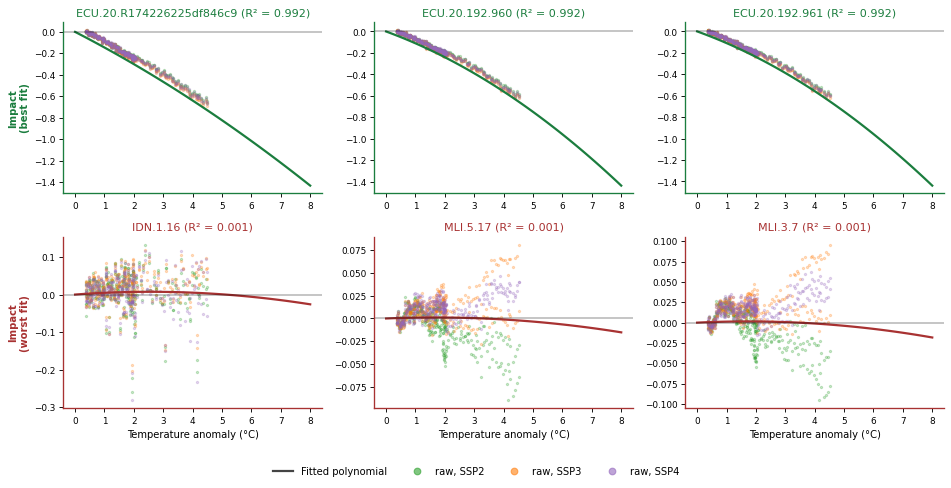

Figure 6: Fitted polynomial with raw data for worst-fitting regions

# 9 Regional Parameter Maps

Maps of key parameters at the **impact region** level. Red = negative (damage increases with T), Blue = positive.

## 9.1 Alpha (Linear Coefficient)

Alpha ($\alpha$) represents the linear sensitivity to temperature. Regions with negative alpha experience damage that increases with the first degree of warming.

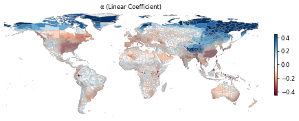

Figure 7: α (linear coefficient)

## 9.2 Beta (Quadratic Coefficient)

Beta ($\beta$) represents the curvature of the damage function.

The concavity ($\beta \leq 0$) constraint is enforced for this sector, meaning optimal temperature exists, damages accelerate beyond it.

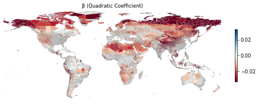

Figure 8: β (quadratic coefficient)

## 9.3 R-squared (Fit Quality)

$R^2$ measures the polynomial fit quality. Higher values indicate that the quadratic form captures more of the variance in the data.

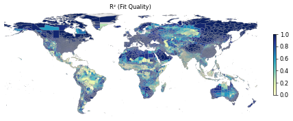

Figure 9: R² (stage 1 fit quality)

# 10 F2: Flex vs Raw Comparison

Comparison of flexible damage function predictions against raw simulation means.

For each scenario (RCP × SSP × Model), we compute at the final year:

- **Flex predicted**: $(\alpha \cdot T + \beta \cdot T^2) \cdot Y^\gamma$
- **Raw actual**: The outcome variable (y) from the source data

**Year 2098**: 292,536 rows

**rcp45**

**SSP2**

**high**

**Correlation:** 0.8476 | **RMSE:** 0.133119 | **Sign agreement:** 93.6%

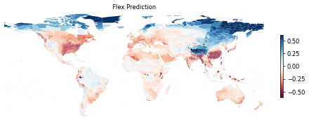

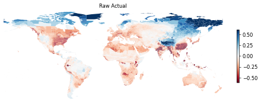

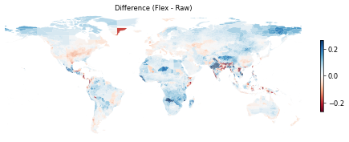

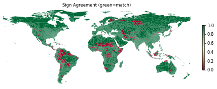

[interactive chart not shown]

Top 5 best predicted Top 5 worst predicted

Year 2098 · T<sub>mean</sub> across these regions: 2.05°C

| Region | Raw | Flex | Residual |
| --- | --- | --- | --- |
| FJI.R13886963f95ae1bc | 0 | 0 | 0 |
| TUV.R06fb643237e8113e | 0 | 0 | 0 |
| USA.45.2797 | 0 | 0 | 0 |
| USA.48.2977 | 0 | 0 | 0 |
| USA.48.2981 | 0 | 0 | 0 |
| IND.20.299.1133 | -1.31 | -0.174 | 1.14 |
| IND.20.299.1131 | -1.25 | -0.176 | 1.07 |
| IND.20.299.1132 | -1.25 | -0.179 | 1.07 |
| IND.20.299.1129 | -1.18 | -0.12 | 1.06 |
| IND.20.275.1044 | -1.16 | -0.103 | 1.06 |

**low**

**Correlation:** 0.8638 | **RMSE:** 0.121769 | **Sign agreement:** 94.2%

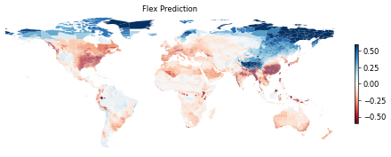

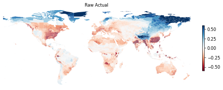

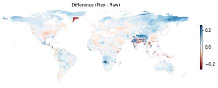

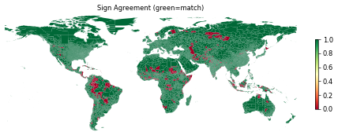

[interactive chart not shown]

Top 5 best predicted Top 5 worst predicted

Year 2098 · T<sub>mean</sub> across these regions: 2.05°C

| Region | Raw | Flex | Residual |
| --- | --- | --- | --- |
| FJI.R13886963f95ae1bc | 0 | 0 | 0 |
| TUV.R06fb643237e8113e | 0 | 0 | 0 |
| USA.45.2797 | 0 | 0 | 0 |
| USA.48.2977 | 0 | 0 | 0 |
| USA.48.2981 | 0 | 0 | 0 |
| IND.35.580.2260 | 0.192 | -0.868 | -1.06 |
| IND.35.580.2258 | 0.0933 | -0.911 | -1 |
| IND.35.580.2259 | -0.149 | -1.08 | -0.928 |
| IND.35.580.2261 | -0.0362 | -0.957 | -0.921 |
| IND.5.64.253 | 0.186 | -0.733 | -0.919 |

**SSP3**

**high**

**Correlation:** 0.8619 | **RMSE:** 0.123813 | **Sign agreement:** 94.0%

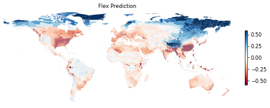

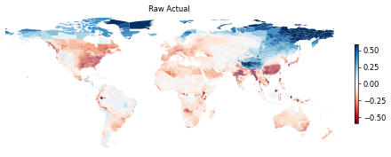

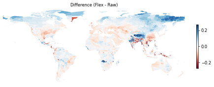

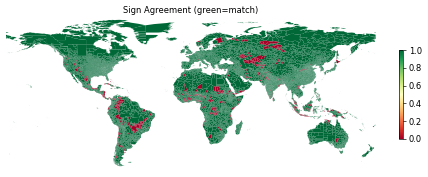

[interactive chart not shown]

Top 5 best predicted Top 5 worst predicted

Year 2098 · T<sub>mean</sub> across these regions: 2.05°C

| Region | Raw | Flex | Residual |
| --- | --- | --- | --- |
| FJI.R13886963f95ae1bc | 0 | 0 | 0 |
| TUV.R06fb643237e8113e | 0 | 0 | 0 |
| USA.45.2797 | 0 | 0 | 0 |
| USA.48.2977 | 0 | 0 | 0 |
| USA.48.2981 | 0 | 0 | 0 |
| IND.35.580.2261 | -0.0691 | -0.998 | -0.929 |
| IND.20.299.1133 | -1.1 | -0.183 | 0.92 |
| IND.35.580.2260 | 0.00692 | -0.906 | -0.913 |
| IND.20.299.1130 | -1.13 | -0.235 | 0.9 |
| IND.20.299.1131 | -1.08 | -0.185 | 0.892 |

**low**

**Correlation:** 0.8663 | **RMSE:** 0.119852 | **Sign agreement:** 93.5%

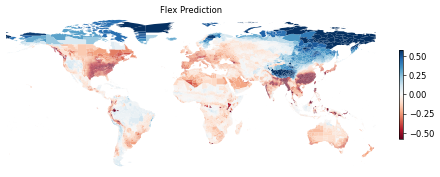

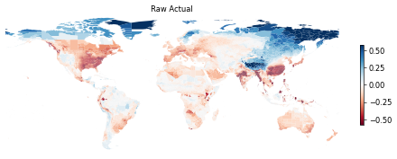

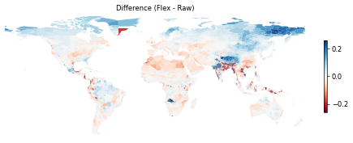

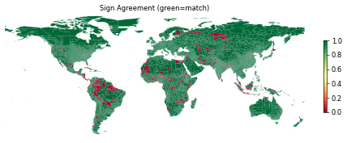

[interactive chart not shown]

Top 5 best predicted Top 5 worst predicted

Year 2098 · T<sub>mean</sub> across these regions: 2.05°C

| Region | Raw | Flex | Residual |
| --- | --- | --- | --- |
| FJI.R13886963f95ae1bc | 0 | 0 | 0 |
| TUV.R06fb643237e8113e | 0 | 0 | 0 |
| USA.45.2797 | 0 | 0 | 0 |
| USA.48.2977 | 0 | 0 | 0 |
| USA.48.2981 | 0 | 0 | 0 |
| IND.35.580.2260 | 0.281 | -0.899 | -1.18 |
| IND.35.580.2259 | 0.032 | -1.12 | -1.15 |
| IND.35.580.2258 | 0.201 | -0.944 | -1.14 |
| IND.35.593.2295 | 0.0118 | -1.12 | -1.13 |
| IND.35.580.2261 | 0.128 | -0.991 | -1.12 |

**SSP4**

**high**

**Correlation:** 0.8517 | **RMSE:** 0.127091 | **Sign agreement:** 93.7%

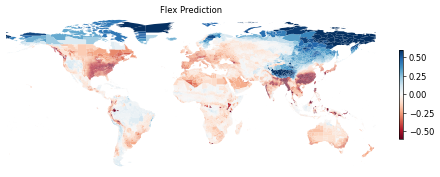

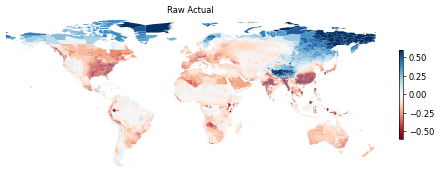

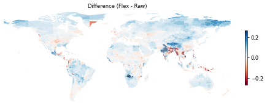

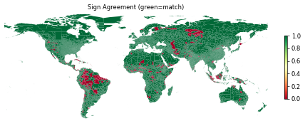

[interactive chart not shown]

Top 5 best predicted Top 5 worst predicted

Year 2098 · T<sub>mean</sub> across these regions: 2.05°C

| Region | Raw | Flex | Residual |
| --- | --- | --- | --- |
| FJI.R13886963f95ae1bc | 0 | 0 | 0 |
| TUV.R06fb643237e8113e | 0 | 0 | 0 |
| USA.45.2797 | 0 | 0 | 0 |
| USA.48.2977 | 0 | 0 | 0 |
| USA.48.2981 | 0 | 0 | 0 |
| IND.35.580.2260 | 0.291 | -0.869 | -1.16 |
| IND.35.580.2259 | -0.0719 | -1.08 | -1.01 |
| IND.12.144.560 | -1.39 | -0.394 | 0.992 |
| IND.12.144.562 | -1.38 | -0.392 | 0.986 |
| IND.12.144.561 | -1.37 | -0.391 | 0.984 |

**low**

**Correlation:** 0.8452 | **RMSE:** 0.128002 | **Sign agreement:** 93.6%

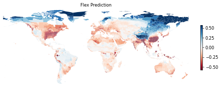

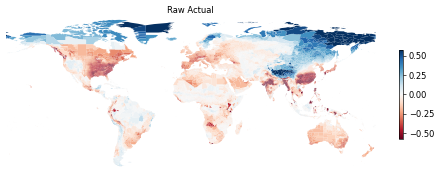

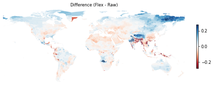

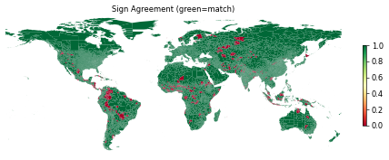

[interactive chart not shown]

Top 5 best predicted Top 5 worst predicted